[figure not shown]

[figure not shown]

# Info

### Intro

Proton Splat League is currently on hiatus, but still, I basically made this for fun. And, I figured I should share it eventually in case it could be useful to somebody else. I wasn’t even part of their stats team. I didn’t choose the nerd life, it chose me.

Anyway, the Tabs description has a pretty good overview of what’s in here. The Overall Results tabs will probably be most helpful, basically just recreating the scoreboard results.

Feel free to open Issues to suggest edits to what’s already here and anything that’d be good to add

### Tabs

- Info
  - Ramblings
  - Todo
- Changelog
  - CHANGELOG.md
    - Includes changelog from before GitHub repos creation
- Overview
  - Table w/ Opponent, maps, scores, and dates
  - Stacked bar plot of W/L ratio per mode
- Heatmap
  - Games clustered by weapon usage with Result, Map, and Mode annotations
- Players
  - Summary stats per weapon (Matches, W/L Ratio, Average K/D, Average Points)
  - Per match results grouped by Mode
  - Plot of overall weapon usage
- Overall Results
  - Recreation of end of match table shown in-game with team and date also given
  - PSL-style match tracking table
  - PSL-style per set weapon usage table

### Todo

- Per row grouping summary stats
- Get interactive heatmap to work

# Changelog

### Changelog

- 2.3.0 - Going Public - 1/19/2025
  - Update header names for Player tables
  - Update grouping for Weapons Mode table
  - Add checks for unexpected results, repos, modes, and players
  - Switch colors for maps in heatmap
  - Set order for Modes in heatmap legend to match usuall PSL mode order
- 2.2.0 - For the Future - 9/6/2024
  - Switch to using Excel file for input
- 2.1.0 - Summer Cleaning - 8/30/2024
  - Remove ‘Anachronox’ from function names
  - Change first select for Scoreboard to use explicit column names
  - Remove code for handling games without assists from Player Weapon Overview Table
  - Change default value for ‘results_string’ parameter
- 2.0.0 - Parties and Plays - 8/3/2024
  - Move CSS settings to separate file
  - Refactor input paths
  - Refactor per player function
  - Add running PSL Players Stats
  - Add PSL Player Stats table
  - Add PSL Weapon Usage table
  - Add exports for tables
  - Split source files by color definition vs function
  - Remove V1 table parsing function
  - Set defaults for chunks
  - Make spacing more consistent
  - Move changelog into separate tab
  - Split Info tab into subsections
  - Add page navigation back in for tables
  - Remove autowidth
  - Change table sizing
  - Fix per set missing player issue
  - Add dynamic player page generation
- 1.4.0 - Not Applicable - 6/2/2024
  - Add support for player summary table w/ disconnects
- 1.3.2 - I Am Legend - 5/19/2024
  - Fix heat map legend getting cut off
- 1.3.1 - Weapons Ready - 5/13/2024
  - Swap order for Main and Player in Overall Results table
- 1.3 - Results May Vary - 4/20/2024
  - Add support for sets w/ and without assists
- 1.2 - Totally Tabular - 4/6/2024
  - Add additional columns and groupings to player summary table
  - Add special counts back in to match table
- 1.1 - Catching Fire - 4/4/2024
  - Added results for 3/28/24
  - Updated names
- 1.0.0 - The Lorax - 3/15/2024
  - Added visuals for weapon usage
  - Has to be specified manually though
- 0.5.0 - Spring Cleaning - 3/9/2024
  - Added support for missing players on focused team
  - Cleanup individual player list structure
  - Add filter for player weapon use details

# Overview

### Overview Table

|  | Opponent_Team | Date | Month | Year | TeamScore | OpposingScore | Modes_Maps |
| --- | --- | --- | --- | --- | --- | --- | --- |
| 1 | OpponentTeam1 | 08_21_2024 | August | 2024 | 14 | 1 | Clam-Blitz-Shipshape-Cargo-Co, Rainmaker-Humpback-Pump-Track, Splat-Zones-Barnacle-&amp;-Dime, Tower-Control-Undertow-Spillway, Turf-War-MakoMart |
| 2 | OpponentTeam2 | 08_22_2024 | August | 2024 | 11 | 5 | Clam-Blitz-Barnacle-&amp;-Dime, Rainmaker-Eeltail-Alley, Splat-Zones-Crableg-Capital, Tower-Control-Marlin-Airport, Turf-War-Wahoo-World |
| 3 | OpponentTeam3 | 08_24_2024 | August | 2024 | 7 | 8 | Clam-Blitz-Um-ami-Ruins, Rainmaker-Manta-Maria, Splat-Zones-Mincemeat-Metalworks, Tower-Control-Sturgeon-Shipyard, Turf-War-Hammerhead-Bridge |
| 4 | Total |  |  | 2024 | 32 | 14 |  |

### Mode Summary

[interactive chart not shown]

# Heatmap

### Heatmap

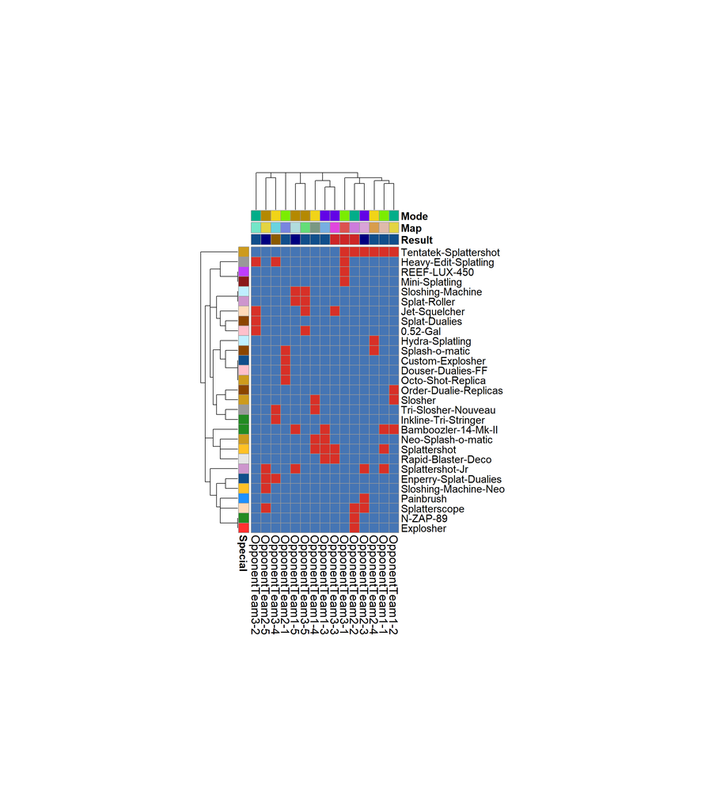

### Legend

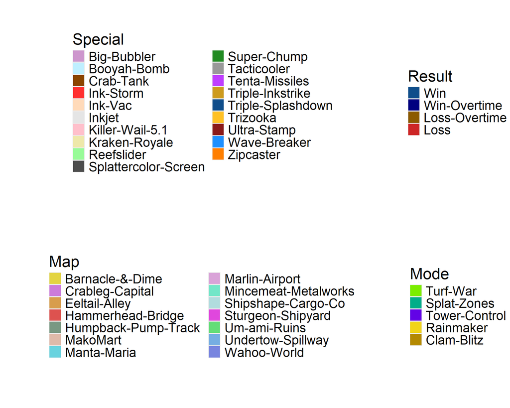

# Player-6

### Weapons Overview

[interactive table not shown]

### Weapons Details

| Mode | Result | Opponent_Team | Date | Map | Main | Points | K + A | Kills | Assists | Deaths | Specials |
| --- | --- | --- | --- | --- | --- | --- | --- | --- | --- | --- | --- |
| Turf-War | Win | OpponentTeam2 | 08_22_2024 | Wahoo-World | Douser-Dualies-FF | 913 | 6 | 2 | 4 | 3 | 4 |
| Tower-Control | Win | OpponentTeam1 | 08_21_2024 | Undertow-Spillway | Rapid-Blaster-Deco | 369 | 5 | 1 | 4 | 0 | 1 |
| Tower-Control | Win-Overtime | OpponentTeam2 | 08_22_2024 | Marlin-Airport | Painbrush | 1226 | 8 | 5 | 3 | 10 | 5 |
| Tower-Control | Loss | OpponentTeam3 | 08_24_2024 | Sturgeon-Shipyard | Rapid-Blaster-Deco | 693 | 4 | 2 | 2 | 7 | 2 |
| Rainmaker | Win | OpponentTeam1 | 08_21_2024 | Humpback-Pump-Track | Tri-Slosher-Nouveau | 491 | 6 | 5 | 1 | 2 | 1 |
| Rainmaker | Loss-Overtime | OpponentTeam3 | 08_24_2024 | Manta-Maria | Tri-Slosher-Nouveau | 1301 | 8 | 3 | 5 | 11 | 5 |
| Clam-Blitz | Win-Overtime | OpponentTeam1 | 08_21_2024 | Shipshape-Cargo-Co | Splat-Roller | 1026 | 18 | 16 | 2 | 12 | 3 |
| Clam-Blitz | Win | OpponentTeam3 | 08_24_2024 | Um-ami-Ruins | Splat-Roller | 720 | 6 | 5 | 1 | 7 | 2 |

### Weapons Usage

[interactive chart not shown]

# Player-4

### Weapons Overview

[interactive table not shown]

### Weapons Details

| Mode | Result | Opponent_Team | Date | Map | Main | Points | K + A | Kills | Assists | Deaths | Specials |
| --- | --- | --- | --- | --- | --- | --- | --- | --- | --- | --- | --- |
| Turf-War | Win | OpponentTeam1 | 08_21_2024 | MakoMart | Bamboozler-14-Mk-II | 792 | 4 | 2 | 2 | 1 | 2 |
| Turf-War | Win | OpponentTeam2 | 08_22_2024 | Wahoo-World | Octo-Shot-Replica | 824 | 4 | 4 | 0 | 4 | 2 |
| Turf-War | Loss | OpponentTeam3 | 08_24_2024 | Hammerhead-Bridge | Tentatek-Splattershot | 1061 | 4 | 3 | 1 | 5 | 4 |
| Splat-Zones | Win | OpponentTeam1 | 08_21_2024 | Barnacle-&amp;-Dime | Bamboozler-14-Mk-II | 337 | 2 | 1 | 1 | 0 | 1 |
| Splat-Zones | Loss | OpponentTeam2 | 08_22_2024 | Crableg-Capital | N-ZAP-89 | 1413 | 5 | 5 | 0 | 7 | 4 |
| Tower-Control | Win | OpponentTeam1 | 08_21_2024 | Undertow-Spillway | Bamboozler-14-Mk-II | 296 | 2 | 0 | 2 | 0 | 1 |
| Tower-Control | Win-Overtime | OpponentTeam2 | 08_22_2024 | Marlin-Airport | Splattershot-Jr | 1283 | 4 | 3 | 1 | 13 | 3 |
| Clam-Blitz | Win-Overtime | OpponentTeam2 | 08_22_2024 | Barnacle-&amp;-Dime | Splattershot-Jr | 1319 | 5 | 4 | 1 | 7 | 4 |

### Weapons Usage

[interactive chart not shown]

# Player-2

### Weapons Overview

[interactive table not shown]

### Weapons Details

| Mode | Result | Opponent_Team | Date | Map | Main | Points | K + A | Kills | Assists | Deaths | Specials |
| --- | --- | --- | --- | --- | --- | --- | --- | --- | --- | --- | --- |
| Turf-War | Win | OpponentTeam1 | 08_21_2024 | MakoMart | Tentatek-Splattershot | 994 | 10 | 8 | 2 | 4 | 3 |
| Turf-War | Win | OpponentTeam2 | 08_22_2024 | Wahoo-World | Splash-o-matic | 1200 | 7 | 7 | 0 | 3 | 5 |
| Turf-War | Loss | OpponentTeam3 | 08_24_2024 | Hammerhead-Bridge | REEF-LUX-450 | 1181 | 3 | 2 | 1 | 3 | 4 |
| Splat-Zones | Win | OpponentTeam1 | 08_21_2024 | Barnacle-&amp;-Dime | Tentatek-Splattershot | 369 | 1 | 1 | 0 | 3 | 1 |
| Splat-Zones | Win | OpponentTeam3 | 08_24_2024 | Mincemeat-Metalworks | 0.52-Gal | 1207 | 6 | 5 | 1 | 3 | 5 |
| Tower-Control | Win | OpponentTeam1 | 08_21_2024 | Undertow-Spillway | Neo-Splash-o-matic | 452 | 4 | 3 | 1 | 1 | 2 |
| Tower-Control | Loss | OpponentTeam3 | 08_24_2024 | Sturgeon-Shipyard | Splattershot | 930 | 5 | 5 | 0 | 8 | 3 |
| Rainmaker | Win | OpponentTeam1 | 08_21_2024 | Humpback-Pump-Track | Neo-Splash-o-matic | 359 | 4 | 2 | 2 | 3 | 0 |
| Rainmaker | Win | OpponentTeam2 | 08_22_2024 | Eeltail-Alley | Splash-o-matic | 701 | 10 | 10 | 0 | 6 | 3 |
| Clam-Blitz | Win | OpponentTeam3 | 08_24_2024 | Um-ami-Ruins | 0.52-Gal | 692 | 9 | 7 | 2 | 6 | 2 |

### Weapons Usage

[interactive chart not shown]

# Player-1

### Weapons Overview

[interactive table not shown]

### Weapons Details

| Mode | Result | Opponent_Team | Date | Map | Main | Points | K + A | Kills | Assists | Deaths | Specials |
| --- | --- | --- | --- | --- | --- | --- | --- | --- | --- | --- | --- |
| Turf-War | Win | OpponentTeam1 | 08_21_2024 | MakoMart | Splattershot | 1071 | 10 | 9 | 1 | 4 | 3 |
| Splat-Zones | Win | OpponentTeam1 | 08_21_2024 | Barnacle-&amp;-Dime | Order-Dualie-Replicas | 437 | 6 | 5 | 1 | 1 | 1 |
| Splat-Zones | Loss | OpponentTeam2 | 08_22_2024 | Crableg-Capital | Tentatek-Splattershot | 1126 | 12 | 11 | 1 | 5 | 4 |
| Splat-Zones | Win | OpponentTeam3 | 08_24_2024 | Mincemeat-Metalworks | Splat-Dualies | 1066 | 11 | 9 | 2 | 5 | 3 |
| Tower-Control | Win | OpponentTeam1 | 08_21_2024 | Undertow-Spillway | Splattershot | 522 | 9 | 9 | 0 | 0 | 2 |
| Tower-Control | Win-Overtime | OpponentTeam2 | 08_22_2024 | Marlin-Airport | Tentatek-Splattershot | 2055 | 31 | 29 | 2 | 6 | 8 |
| Tower-Control | Loss | OpponentTeam3 | 08_24_2024 | Sturgeon-Shipyard | Splattershot | 953 | 11 | 9 | 2 | 6 | 4 |
| Rainmaker | Win | OpponentTeam1 | 08_21_2024 | Humpback-Pump-Track | Splattershot | 547 | 5 | 4 | 1 | 1 | 2 |
| Rainmaker | Win | OpponentTeam2 | 08_22_2024 | Eeltail-Alley | Tentatek-Splattershot | 953 | 12 | 11 | 1 | 3 | 2 |
| Rainmaker | Loss-Overtime | OpponentTeam3 | 08_24_2024 | Manta-Maria | Enperry-Splat-Dualies | 1129 | 9 | 8 | 1 | 8 | 5 |

[output cut: 3 more lines]

### Weapons Usage

[interactive chart not shown]

# Player-5

### Weapons Overview

[interactive table not shown]

### Weapons Details

| Mode | Result | Opponent_Team | Date | Map | Main | Points | K + A | Kills | Assists | Deaths | Specials |
| --- | --- | --- | --- | --- | --- | --- | --- | --- | --- | --- | --- |
| Turf-War | Win | OpponentTeam2 | 08_22_2024 | Wahoo-World | Custom-Explosher | 741 | 5 | 4 | 1 | 4 | 3 |
| Turf-War | Loss | OpponentTeam3 | 08_24_2024 | Hammerhead-Bridge | Mini-Splatling | 936 | 4 | 4 | 0 | 4 | 4 |
| Splat-Zones | Win | OpponentTeam1 | 08_21_2024 | Barnacle-&amp;-Dime | Slosher | 372 | 4 | 3 | 1 | 2 | 1 |
| Splat-Zones | Loss | OpponentTeam2 | 08_22_2024 | Crableg-Capital | Explosher | 1024 | 5 | 3 | 2 | 7 | 3 |
| Splat-Zones | Win | OpponentTeam3 | 08_24_2024 | Mincemeat-Metalworks | Heavy-Edit-Splatling | 851 | 5 | 3 | 2 | 3 | 3 |
| Rainmaker | Win | OpponentTeam1 | 08_21_2024 | Humpback-Pump-Track | Slosher | 437 | 3 | 1 | 2 | 0 | 1 |
| Rainmaker | Win | OpponentTeam2 | 08_22_2024 | Eeltail-Alley | Hydra-Splatling | 521 | 4 | 2 | 2 | 5 | 1 |
| Rainmaker | Loss-Overtime | OpponentTeam3 | 08_24_2024 | Manta-Maria | Heavy-Edit-Splatling | 1058 | 7 | 6 | 1 | 11 | 4 |
| Clam-Blitz | Win-Overtime | OpponentTeam1 | 08_21_2024 | Shipshape-Cargo-Co | Sloshing-Machine | 1398 | 12 | 6 | 6 | 6 | 4 |
| Clam-Blitz | Win-Overtime | OpponentTeam2 | 08_22_2024 | Barnacle-&amp;-Dime | Sloshing-Machine-Neo | 1218 | 16 | 9 | 7 | 4 | 7 |

### Weapons Usage

[interactive chart not shown]

# Player-3

### Weapons Overview

[interactive table not shown]

### Weapons Details

| Mode | Result | Opponent_Team | Date | Map | Main | Points | K + A | Kills | Assists | Deaths | Specials |
| --- | --- | --- | --- | --- | --- | --- | --- | --- | --- | --- | --- |
| Turf-War | Win | OpponentTeam1 | 08_21_2024 | MakoMart | Splattershot-Jr | 963 | 6 | 3 | 3 | 4 | 3 |
| Turf-War | Loss | OpponentTeam3 | 08_24_2024 | Hammerhead-Bridge | Heavy-Edit-Splatling | 857 | 4 | 0 | 4 | 3 | 3 |
| Splat-Zones | Loss | OpponentTeam2 | 08_22_2024 | Crableg-Capital | Splatterscope | 1104 | 13 | 2 | 11 | 2 | 4 |
| Splat-Zones | Win | OpponentTeam3 | 08_24_2024 | Mincemeat-Metalworks | Jet-Squelcher | 990 | 5 | 2 | 3 | 2 | 4 |
| Tower-Control | Win-Overtime | OpponentTeam2 | 08_22_2024 | Marlin-Airport | Splatterscope | 1280 | 9 | 1 | 8 | 3 | 6 |
| Tower-Control | Loss | OpponentTeam3 | 08_24_2024 | Sturgeon-Shipyard | Jet-Squelcher | 830 | 11 | 3 | 8 | 3 | 4 |
| Rainmaker | Loss-Overtime | OpponentTeam3 | 08_24_2024 | Manta-Maria | Inkline-Tri-Stringer | 1201 | 6 | 4 | 2 | 6 | 7 |
| Clam-Blitz | Win-Overtime | OpponentTeam1 | 08_21_2024 | Shipshape-Cargo-Co | Splattershot-Jr | 1238 | 3 | 3 | 0 | 8 | 2 |
| Clam-Blitz | Win-Overtime | OpponentTeam2 | 08_22_2024 | Barnacle-&amp;-Dime | Splatterscope | 1271 | 18 | 3 | 15 | 4 | 5 |
| Clam-Blitz | Win | OpponentTeam3 | 08_24_2024 | Um-ami-Ruins | Jet-Squelcher | 799 | 11 | 2 | 9 | 1 | 3 |

### Weapons Usage

[interactive chart not shown]

# Scoreboards

|  | Result | Knockout | Opponent_Team | Date | Map | Mode | Main | Player | Points | Splats | Deaths | Specials | Opposing_Player | Opposing_Main | Opposing_Points | Opposing_Splats | Opposing_Deaths | Opposing_Specials |
| --- | --- | --- | --- | --- | --- | --- | --- | --- | --- | --- | --- | --- | --- | --- | --- | --- | --- | --- |
| 1 | Win |  | OpponentTeam1 | 08_21_2024 | MakoMart | Turf-War | Splattershot | Player-1 | 1071 | 10 &lt;1&gt; | 4 | 3 | Opp-3 | Splattershot | 858 | 5 &lt;1&gt; | 5 | 3 |
| 2 | Win |  | OpponentTeam1 | 08_21_2024 | MakoMart | Turf-War | Tentatek-Splattershot | Player-2 | 994 | 10 &lt;2&gt; | 4 | 3 | Opp-2 | Neo-Sploosh-o-matic | 921 | 4 | 5 | 3 |
| 3 | Win |  | OpponentTeam1 | 08_21_2024 | MakoMart | Turf-War | Splattershot-Jr | Player-3 | 963 | 6 &lt;3&gt; | 4 | 3 | Opp-4 | Splatana-Stamper | 799 | 4 &lt;1&gt; | 7 | 2 |
| 4 | Win |  | OpponentTeam1 | 08_21_2024 | MakoMart | Turf-War | Bamboozler-14-Mk-II | Player-4 | 792 | 4 &lt;2&gt; | 1 | 2 | Opp-1 | Inkbrush | 956 | 3 &lt;1&gt; | 6 | 3 |
| 5 | Win | Y | OpponentTeam1 | 08_21_2024 | Barnacle-&amp;-Dime | Splat-Zones | Order-Dualie-Replicas | Player-1 | 437 | 6 &lt;1&gt; | 1 | 1 | Opp-3 | Splattershot | 417 | 4 &lt;1&gt; | 2 | 1 |
| 6 | Win | Y | OpponentTeam1 | 08_21_2024 | Barnacle-&amp;-Dime | Splat-Zones | Slosher | Player-5 | 372 | 4 &lt;1&gt; | 2 | 1 | Opp-2 | Jet-Squelcher | 524 | 2 &lt;1&gt; | 2 | 2 |
| 7 | Win | Y | OpponentTeam1 | 08_21_2024 | Barnacle-&amp;-Dime | Splat-Zones | Bamboozler-14-Mk-II | Player-4 | 337 | 2 &lt;1&gt; | 0 | 1 | Opp-1 | Splatana-Stamper | 239 | 1 | 4 | 2 |
| 8 | Win | Y | OpponentTeam1 | 08_21_2024 | Barnacle-&amp;-Dime | Splat-Zones | Tentatek-Splattershot | Player-2 | 369 | 1 | 3 | 1 | Opp-4 | Enperry-Splat-Dualies | 276 | 1 | 3 | 0 |
| 9 | Win | Y | OpponentTeam1 | 08_21_2024 | Undertow-Spillway | Tower-Control | Splattershot | Player-1 | 522 | 9 | 0 | 2 | Opp-2 | Jet-Squelcher | 422 | 1 &lt;1&gt; | 2 | 1 |
| 10 | Win | Y | OpponentTeam1 | 08_21_2024 | Undertow-Spillway | Tower-Control | Bamboozler-14-Mk-II | Player-4 | 296 | 2 &lt;2&gt; | 0 | 1 | Opp-4 | Dread-Wringer | 403 | 0 | 3 | 0 |

[output cut: 50 more lines]

# PSL Player Stats

### PSL Player Stats Per Set

|  | Player | Opponent_Team | Date | Games_Played | Kills | Assists | Deaths | Specials_Used | Turf_Inked_TW_only |
| --- | --- | --- | --- | --- | --- | --- | --- | --- | --- |
| 1 | Player-6 | OpponentTeam1 | 08_21_2024 | 3 | 22 | 7 | 14 | 5 |  |
| 2 | Player-4 | OpponentTeam1 | 08_21_2024 | 3 | 3 | 5 | 1 | 4 | 792 |
| 3 | Player-2 | OpponentTeam1 | 08_21_2024 | 4 | 14 | 5 | 11 | 6 | 994 |
| 4 | Player-1 | OpponentTeam1 | 08_21_2024 | 5 | 37 | 10 | 7 | 14 | 1071 |
| 5 | Player-5 | OpponentTeam1 | 08_21_2024 | 3 | 10 | 9 | 8 | 6 |  |
| 6 | Player-3 | OpponentTeam1 | 08_21_2024 | 2 | 6 | 3 | 12 | 5 | 963 |
| 7 | Player-6 | OpponentTeam2 | 08_22_2024 | 2 | 7 | 7 | 13 | 9 | 913 |
| 8 | Player-4 | OpponentTeam2 | 08_22_2024 | 4 | 16 | 2 | 31 | 13 | 824 |
| 9 | Player-2 | OpponentTeam2 | 08_22_2024 | 2 | 17 | 0 | 9 | 8 | 1200 |
| 10 | Player-1 | OpponentTeam2 | 08_22_2024 | 4 | 70 | 5 | 22 | 19 |  |

[output cut: 8 more lines]

### PSL Player Stats

|  | Player | Matches_Played | Games_Played | Kills | Assists | Deaths | Specials_Used | Turf_Inked_TW_only |
| --- | --- | --- | --- | --- | --- | --- | --- | --- |
| 1 | Player-6 | 3 | 8 | 39 | 22 | 52 | 23 | 913 |
| 2 | Player-4 | 3 | 8 | 22 | 8 | 37 | 21 | 2677 |
| 3 | Player-2 | 3 | 10 | 50 | 9 | 40 | 28 | 3375 |
| 4 | Player-1 | 3 | 13 | 142 | 21 | 53 | 48 | 1071 |
| 5 | Player-5 | 3 | 10 | 41 | 24 | 46 | 31 | 1677 |
| 6 | Player-3 | 3 | 10 | 23 | 63 | 36 | 41 | 1820 |

# PSL Weapon Usage

|  | Player | Opponent_Team | Date | Turf-War | Splat-Zones | Tower-Control | Rainmaker | Clam-Blitz | Modes_Maps |
| --- | --- | --- | --- | --- | --- | --- | --- | --- | --- |
| 1 | Player-6 | OpponentTeam1 | 08_21_2024 |  |  | Rapid-Blaster-Deco | Tri-Slosher-Nouveau | Splat-Roller | Clam-Blitz-Shipshape-Cargo-Co, Rainmaker-Humpback-Pump-Track, Splat-Zones-Barnacle-&amp;-Dime, Tower-Control-Undertow-Spillway, Turf-War-MakoMart |
| 2 | Player-4 | OpponentTeam1 | 08_21_2024 | Bamboozler-14-Mk-II | Bamboozler-14-Mk-II | Bamboozler-14-Mk-II |  |  | Clam-Blitz-Shipshape-Cargo-Co, Rainmaker-Humpback-Pump-Track, Splat-Zones-Barnacle-&amp;-Dime, Tower-Control-Undertow-Spillway, Turf-War-MakoMart |
| 3 | Player-2 | OpponentTeam1 | 08_21_2024 | Tentatek-Splattershot | Tentatek-Splattershot | Neo-Splash-o-matic | Neo-Splash-o-matic |  | Clam-Blitz-Shipshape-Cargo-Co, Rainmaker-Humpback-Pump-Track, Splat-Zones-Barnacle-&amp;-Dime, Tower-Control-Undertow-Spillway, Turf-War-MakoMart |
| 4 | Player-1 | OpponentTeam1 | 08_21_2024 | Splattershot | Order-Dualie-Replicas | Splattershot | Splattershot | Bamboozler-14-Mk-II | Clam-Blitz-Shipshape-Cargo-Co, Rainmaker-Humpback-Pump-Track, Splat-Zones-Barnacle-&amp;-Dime, Tower-Control-Undertow-Spillway, Turf-War-MakoMart |
| 5 | Player-5 | OpponentTeam1 | 08_21_2024 |  | Slosher |  | Slosher | Sloshing-Machine | Clam-Blitz-Shipshape-Cargo-Co, Rainmaker-Humpback-Pump-Track, Splat-Zones-Barnacle-&amp;-Dime, Tower-Control-Undertow-Spillway, Turf-War-MakoMart |
| 6 | Player-3 | OpponentTeam1 | 08_21_2024 | Splattershot-Jr |  |  |  | Splattershot-Jr | Clam-Blitz-Shipshape-Cargo-Co, Rainmaker-Humpback-Pump-Track, Splat-Zones-Barnacle-&amp;-Dime, Tower-Control-Undertow-Spillway, Turf-War-MakoMart |
| 7 | Player-6 | OpponentTeam2 | 08_22_2024 | Douser-Dualies-FF |  | Painbrush |  |  | Clam-Blitz-Barnacle-&amp;-Dime, Rainmaker-Eeltail-Alley, Splat-Zones-Crableg-Capital, Tower-Control-Marlin-Airport, Turf-War-Wahoo-World |
| 8 | Player-4 | OpponentTeam2 | 08_22_2024 | Octo-Shot-Replica | N-ZAP-89 | Splattershot-Jr |  | Splattershot-Jr | Clam-Blitz-Barnacle-&amp;-Dime, Rainmaker-Eeltail-Alley, Splat-Zones-Crableg-Capital, Tower-Control-Marlin-Airport, Turf-War-Wahoo-World |
| 9 | Player-2 | OpponentTeam2 | 08_22_2024 | Splash-o-matic |  |  | Splash-o-matic |  | Clam-Blitz-Barnacle-&amp;-Dime, Rainmaker-Eeltail-Alley, Splat-Zones-Crableg-Capital, Tower-Control-Marlin-Airport, Turf-War-Wahoo-World |
| 10 | Player-1 | OpponentTeam2 | 08_22_2024 |  | Tentatek-Splattershot | Tentatek-Splattershot | Tentatek-Splattershot | Enperry-Splat-Dualies | Clam-Blitz-Barnacle-&amp;-Dime, Rainmaker-Eeltail-Alley, Splat-Zones-Crableg-Capital, Tower-Control-Marlin-Airport, Turf-War-Wahoo-World |

[output cut: 8 more lines]